# IP 2 R

Ruth Muriithi

1/15/2021

#Problem Definition

```
Kira Plastinina is a fashion retail store. The brand's Sales and Marketing team would like to understand their customer’s behavior from data that they have collected over the past year. More specifically, they would like to learn the characteristics of customer groups.
```

#Data Sourcing

We are provided with a link for the dataset.

```r
mydata <- read.csv("http://bit.ly/EcommerceCustomersDataset")
head(mydata)
```

```
##   Administrative Administrative_Duration Informational Informational_Duration
## 1              0                       0             0                      0
## 2              0                       0             0                      0
## 3              0                      -1             0                     -1
## 4              0                       0             0                      0
## 5              0                       0             0                      0
## 6              0                       0             0                      0
##   ProductRelated ProductRelated_Duration BounceRates ExitRates PageValues
## 1              1                0.000000  0.20000000 0.2000000          0
## 2              2               64.000000  0.00000000 0.1000000          0
## 3              1               -1.000000  0.20000000 0.2000000          0
## 4              2                2.666667  0.05000000 0.1400000          0
## 5             10              627.500000  0.02000000 0.0500000          0
## 6             19              154.216667  0.01578947 0.0245614          0
##   SpecialDay Month OperatingSystems Browser Region TrafficType
## 1          0   Feb                1       1      1           1
## 2          0   Feb                2       2      1           2
## 3          0   Feb                4       1      9           3
## 4          0   Feb                3       2      2           4
## 5          0   Feb                3       3      1           4
## 6          0   Feb                2       2      1           3
##         VisitorType Weekend Revenue
## 1 Returning_Visitor   FALSE   FALSE
## 2 Returning_Visitor   FALSE   FALSE
## 3 Returning_Visitor   FALSE   FALSE
## 4 Returning_Visitor   FALSE   FALSE
## 5 Returning_Visitor    TRUE   FALSE
## 6 Returning_Visitor   FALSE   FALSE
```

#Check the Data

```r
library(tidyverse)
str(mydata)
```

```
## 'data.frame':    12330 obs. of  18 variables:
##  $ Administrative         : int  0 0 0 0 0 0 0 1 0 0 ...
##  $ Administrative_Duration: num  0 0 -1 0 0 0 -1 -1 0 0 ...
##  $ Informational          : int  0 0 0 0 0 0 0 0 0 0 ...
##  $ Informational_Duration : num  0 0 -1 0 0 0 -1 -1 0 0 ...
##  $ ProductRelated         : int  1 2 1 2 10 19 1 1 2 3 ...
##  $ ProductRelated_Duration: num  0 64 -1 2.67 627.5 ...
##  $ BounceRates            : num  0.2 0 0.2 0.05 0.02 ...
##  $ ExitRates              : num  0.2 0.1 0.2 0.14 0.05 ...
##  $ PageValues             : num  0 0 0 0 0 0 0 0 0 0 ...
##  $ SpecialDay             : num  0 0 0 0 0 0 0.4 0 0.8 0.4 ...
##  $ Month                  : chr  "Feb" "Feb" "Feb" "Feb" ...
##  $ OperatingSystems       : int  1 2 4 3 3 2 2 1 2 2 ...
##  $ Browser                : int  1 2 1 2 3 2 4 2 2 4 ...
##  $ Region                 : int  1 1 9 2 1 1 3 1 2 1 ...
##  $ TrafficType            : int  1 2 3 4 4 3 3 5 3 2 ...
##  $ VisitorType            : chr  "Returning_Visitor" "Returning_Visitor" "Returning_Visitor" "Returning_Visitor" ...
##  $ Weekend                : logi  FALSE FALSE FALSE FALSE TRUE FALSE ...
##  $ Revenue                : logi  FALSE FALSE FALSE FALSE FALSE FALSE ...
```

We have 7 integer variables, 7 numeric, 2 character values and 2 logical variables

```r
summary(mydata)
```

```
##  Administrative   Administrative_Duration Informational
##  Min.   : 0.000   Min.   :  -1.00         Min.   : 0.000
##  1st Qu.: 0.000   1st Qu.:   0.00         1st Qu.: 0.000
##  Median : 1.000   Median :   8.00         Median : 0.000
##  Mean   : 2.318   Mean   :  80.91         Mean   : 0.504
##  3rd Qu.: 4.000   3rd Qu.:  93.50         3rd Qu.: 0.000
##  Max.   :27.000   Max.   :3398.75         Max.   :24.000
##  NA's   :14       NA's   :14              NA's   :14
##  Informational_Duration ProductRelated   ProductRelated_Duration
##  Min.   :  -1.00        Min.   :  0.00   Min.   :   -1.0
##  1st Qu.:   0.00        1st Qu.:  7.00   1st Qu.:  185.0
##  Median :   0.00        Median : 18.00   Median :  599.8
##  Mean   :  34.51        Mean   : 31.76   Mean   : 1196.0
##  3rd Qu.:   0.00        3rd Qu.: 38.00   3rd Qu.: 1466.5
##  Max.   :2549.38        Max.   :705.00   Max.   :63973.5
##  NA's   :14             NA's   :14       NA's   :14
##   BounceRates         ExitRates         PageValues        SpecialDay
##  Min.   :0.000000   Min.   :0.00000   Min.   :  0.000   Min.   :0.00000
##  1st Qu.:0.000000   1st Qu.:0.01429   1st Qu.:  0.000   1st Qu.:0.00000
##  Median :0.003119   Median :0.02512   Median :  0.000   Median :0.00000
##  Mean   :0.022152   Mean   :0.04300   Mean   :  5.889   Mean   :0.06143
##  3rd Qu.:0.016684   3rd Qu.:0.05000   3rd Qu.:  0.000   3rd Qu.:0.00000
##  Max.   :0.200000   Max.   :0.20000   Max.   :361.764   Max.   :1.00000
##  NA's   :14         NA's   :14
##     Month           OperatingSystems    Browser           Region
##  Length:12330       Min.   :1.000    Min.   : 1.000   Min.   :1.000
##  Class :character   1st Qu.:2.000    1st Qu.: 2.000   1st Qu.:1.000
##  Mode  :character   Median :2.000    Median : 2.000   Median :3.000
##                     Mean   :2.124    Mean   : 2.357   Mean   :3.147
##                     3rd Qu.:3.000    3rd Qu.: 2.000   3rd Qu.:4.000
##                     Max.   :8.000    Max.   :13.000   Max.   :9.000
##
##   TrafficType    VisitorType         Weekend         Revenue
##  Min.   : 1.00   Length:12330       Mode :logical   Mode :logical
##  1st Qu.: 2.00   Class :character   FALSE:9462      FALSE:10422
##  Median : 2.00   Mode  :character   TRUE :2868      TRUE :1908
##  Mean   : 4.07
##  3rd Qu.: 4.00
##  Max.   :20.00
##
```

*Checking the number of rows and in our dataset*

```r
cat("Rows in dataset:", nrow(mydata), "\nCols in dataset:", ncol(mydata))
```

```
## Rows in dataset: 12330
## Cols in dataset: 18
```

```r
cat("\nThe dimension of the dataset is:", dim(mydata))
```

```
##
## The dimension of the dataset is: 12330 18
```

#Perform Data Cleaning

*checking for duplicates*

```r
sum(duplicated(mydata))
```

```
## [1] 119
```

There are 119 duplicated values. We are going to drop duplicates.

```r
mydata <- mydata[!duplicated(mydata), ]
sum(duplicated(mydata))
```

```
## [1] 0
```

*Checking for missing values*

```r
cat("\n the columns with missing data are:",colSums(is.na(mydata)))
```

```
##
##  the columns with missing data are: 12 12 12 12 12 12 12 12 0 0 0 0 0 0 0 0 0 0
```

8 out of 18 columns have missing values. I will use the MICE package to impute the missing data in the columns.

*Checking to see if the missing data is above a 5% threshhold to determine whether to drop or impute the data*

```r
pMiss <- function(x){sum(is.na(x))/length(x)*100}
apply(mydata,2,pMiss)
```

```
##          Administrative Administrative_Duration           Informational
##              0.09827205              0.09827205              0.09827205
##  Informational_Duration          ProductRelated ProductRelated_Duration
##              0.09827205              0.09827205              0.09827205
##             BounceRates               ExitRates              PageValues
##              0.09827205              0.09827205              0.00000000
##              SpecialDay                   Month        OperatingSystems
##              0.00000000              0.00000000              0.00000000
##                 Browser                  Region             TrafficType
##              0.00000000              0.00000000              0.00000000
##             VisitorType                 Weekend                 Revenue
##              0.00000000              0.00000000              0.00000000
```

```r
library(VIM)
```

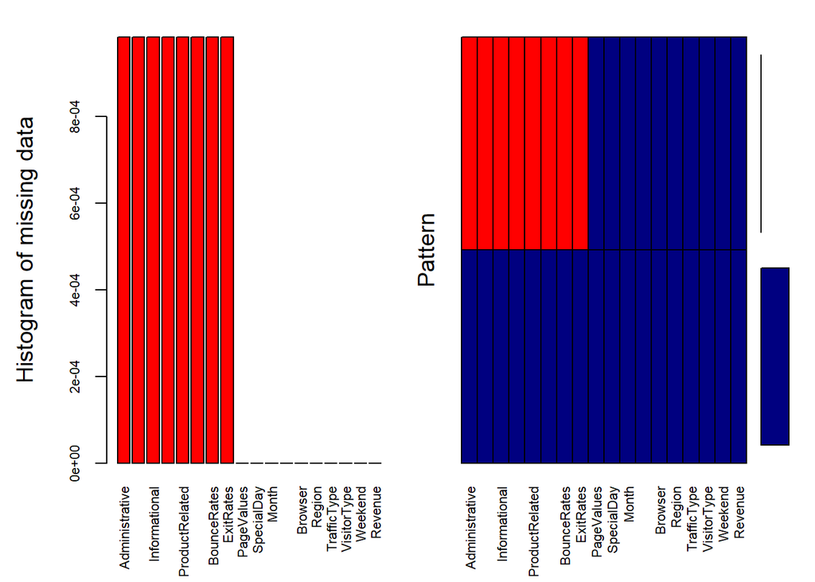

```
##
##  Variables sorted by number of missings:
##                 Variable        Count
##           Administrative 0.0009827205
##  Administrative_Duration 0.0009827205
##            Informational 0.0009827205
##   Informational_Duration 0.0009827205
##           ProductRelated 0.0009827205
##  ProductRelated_Duration 0.0009827205
##              BounceRates 0.0009827205
##                ExitRates 0.0009827205
##               PageValues 0.0000000000
##               SpecialDay 0.0000000000
##                    Month 0.0000000000
##         OperatingSystems 0.0000000000
##                  Browser 0.0000000000
##                   Region 0.0000000000
##              TrafficType 0.0000000000
##              VisitorType 0.0000000000
##                  Weekend 0.0000000000
##                  Revenue 0.0000000000
```

```r
aggr_plot <- aggr(mydata, col=c('navyblue','red'), numbers=TRUE, sortVars=TRUE, labels=names(mydata), cex.axis=.7, gap=3, ylab=c("Histogram of missing data","Pattern"))
```

```r
library(mice)
tempData <- mice(mydata,m=5,maxit=10,meth='pmm',seed=500)
```

*Checking the method of imputation used for each variable*

```r
tempData$meth
```

```
##          Administrative Administrative_Duration           Informational
##                   "pmm"                   "pmm"                   "pmm"
##  Informational_Duration          ProductRelated ProductRelated_Duration
##                   "pmm"                   "pmm"                   "pmm"
##             BounceRates               ExitRates              PageValues
##                   "pmm"                   "pmm"                      ""
##              SpecialDay                   Month        OperatingSystems
##                      ""                      ""                      ""
##                 Browser                  Region             TrafficType
##                      ""                      ""                      ""
##             VisitorType                 Weekend                 Revenue
##                      ""                      ""                      ""
```

```r
is.na(tempData)
```

```
##            data             imp               m           where          blocks
##           FALSE           FALSE           FALSE           FALSE           FALSE
##            call            nmis          method predictorMatrix   visitSequence
##           FALSE           FALSE           FALSE           FALSE           FALSE
##        formulas            post           blots            seed       iteration
##           FALSE           FALSE           FALSE           FALSE           FALSE
##   lastSeedValue       chainMean        chainVar    loggedEvents         version
##           FALSE           FALSE           FALSE           FALSE           FALSE
##            date
##           FALSE
```

Due to the less cases of missing values we are using predictive mean matching as the imputation method. Checking to confirm for any missing values and there are none.

```r
clean.data <- complete(tempData,1)
tail(clean.data)
```

```
##       Administrative Administrative_Duration Informational
## 12206              0                       0             1
## 12207              3                     145             0
## 12208              0                       0             0
## 12209              0                       0             0
## 12210              4                      75             0
## 12211              0                       0             0
##       Informational_Duration ProductRelated ProductRelated_Duration BounceRates
## 12206                      0             16                 503.000 0.000000000
## 12207                      0             53                1783.792 0.007142857
## 12208                      0              5                 465.750 0.000000000
## 12209                      0              6                 184.250 0.083333333
## 12210                      0             15                 346.000 0.000000000
## 12211                      0              3                  21.250 0.000000000
##        ExitRates PageValues SpecialDay Month OperatingSystems Browser Region
## 12206 0.03764706    0.00000          0   Nov                2       2      1
## 12207 0.02903061   12.24172          0   Dec                4       6      1
## 12208 0.02133333    0.00000          0   Nov                3       2      1
## 12209 0.08666667    0.00000          0   Nov                3       2      1
## 12210 0.02105263    0.00000          0   Nov                2       2      3
## 12211 0.06666667    0.00000          0   Nov                3       2      1
##       TrafficType       VisitorType Weekend Revenue
## 12206           1 Returning_Visitor   FALSE   FALSE
## 12207           1 Returning_Visitor    TRUE   FALSE
## 12208           8 Returning_Visitor    TRUE   FALSE
## 12209          13 Returning_Visitor    TRUE   FALSE
## 12210          11 Returning_Visitor   FALSE   FALSE
## 12211           2       New_Visitor    TRUE   FALSE
```

```r
tail(mydata)
```

```
##       Administrative Administrative_Duration Informational
## 12325              0                       0             1
## 12326              3                     145             0
## 12327              0                       0             0
## 12328              0                       0             0
## 12329              4                      75             0
## 12330              0                       0             0
##       Informational_Duration ProductRelated ProductRelated_Duration BounceRates
## 12325                      0             16                 503.000 0.000000000
## 12326                      0             53                1783.792 0.007142857
## 12327                      0              5                 465.750 0.000000000
## 12328                      0              6                 184.250 0.083333333
## 12329                      0             15                 346.000 0.000000000
## 12330                      0              3                  21.250 0.000000000
##        ExitRates PageValues SpecialDay Month OperatingSystems Browser Region
## 12325 0.03764706    0.00000          0   Nov                2       2      1
## 12326 0.02903061   12.24172          0   Dec                4       6      1
## 12327 0.02133333    0.00000          0   Nov                3       2      1
## 12328 0.08666667    0.00000          0   Nov                3       2      1
## 12329 0.02105263    0.00000          0   Nov                2       2      3
## 12330 0.06666667    0.00000          0   Nov                3       2      1
##       TrafficType       VisitorType Weekend Revenue
## 12325           1 Returning_Visitor   FALSE   FALSE
## 12326           1 Returning_Visitor    TRUE   FALSE
## 12327           8 Returning_Visitor    TRUE   FALSE
## 12328          13 Returning_Visitor    TRUE   FALSE
## 12329          11 Returning_Visitor   FALSE   FALSE
## 12330           2       New_Visitor    TRUE   FALSE
```

*Checking for outliers*

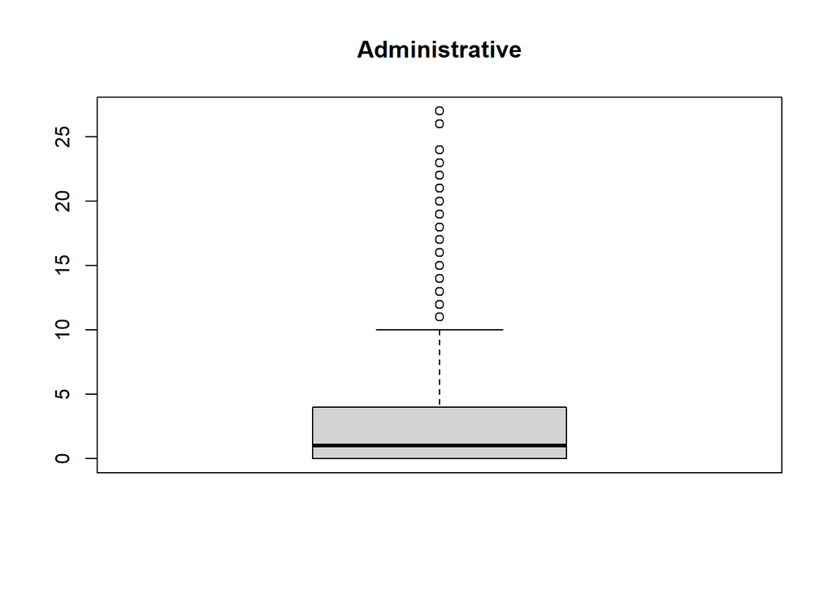

```
## [1] 1
```

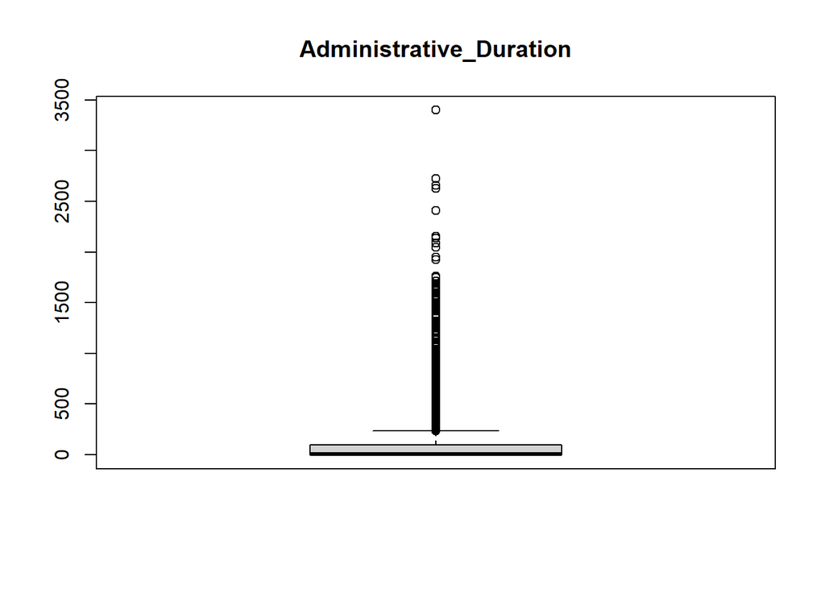

```
## [1] 2
```

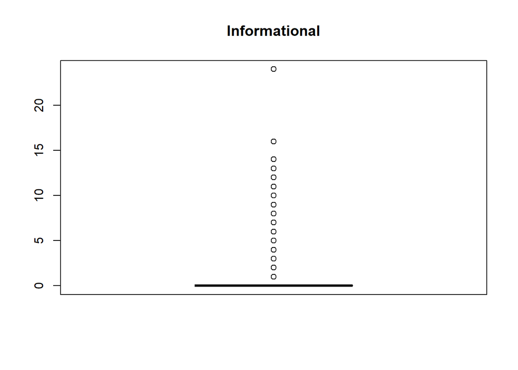

```
## [1] 3
```

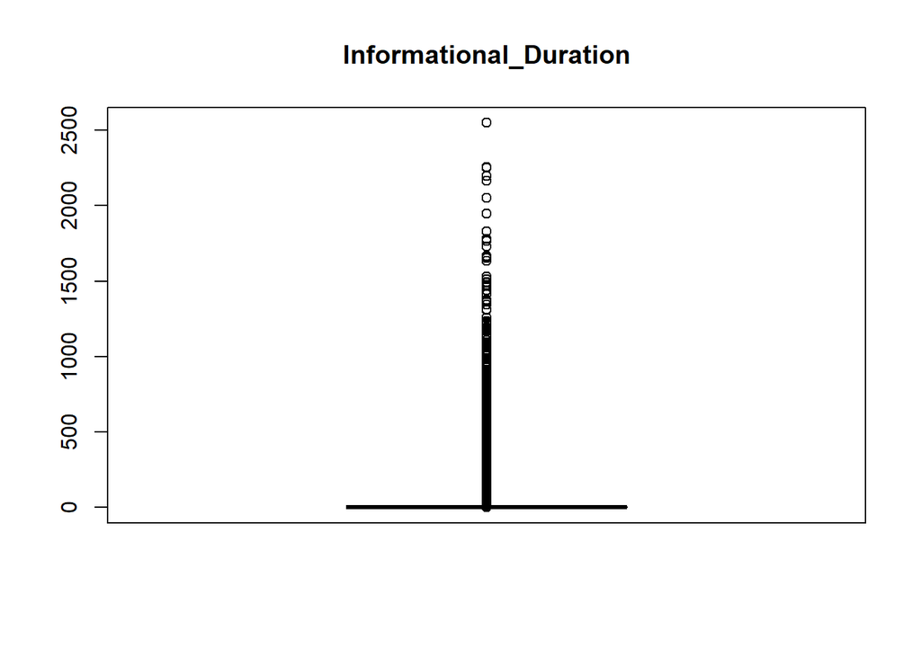

```
## [1] 4
```

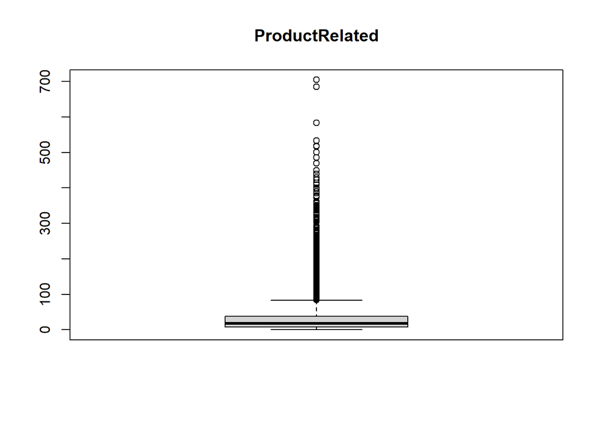

```
## [1] 5
```

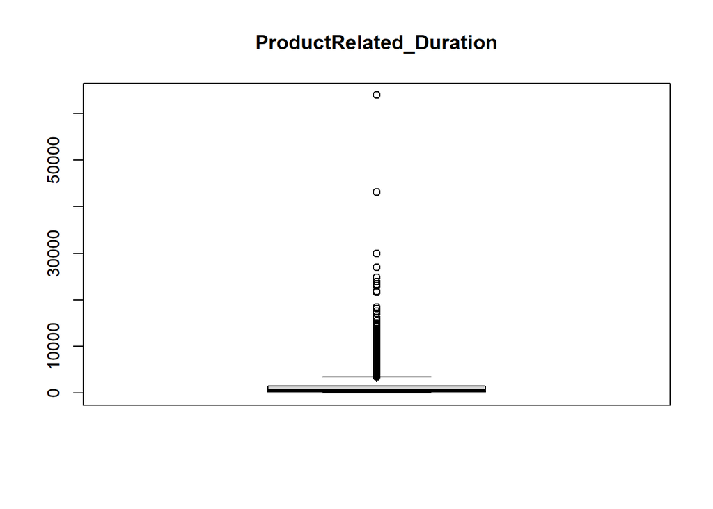

```
## [1] 6
```

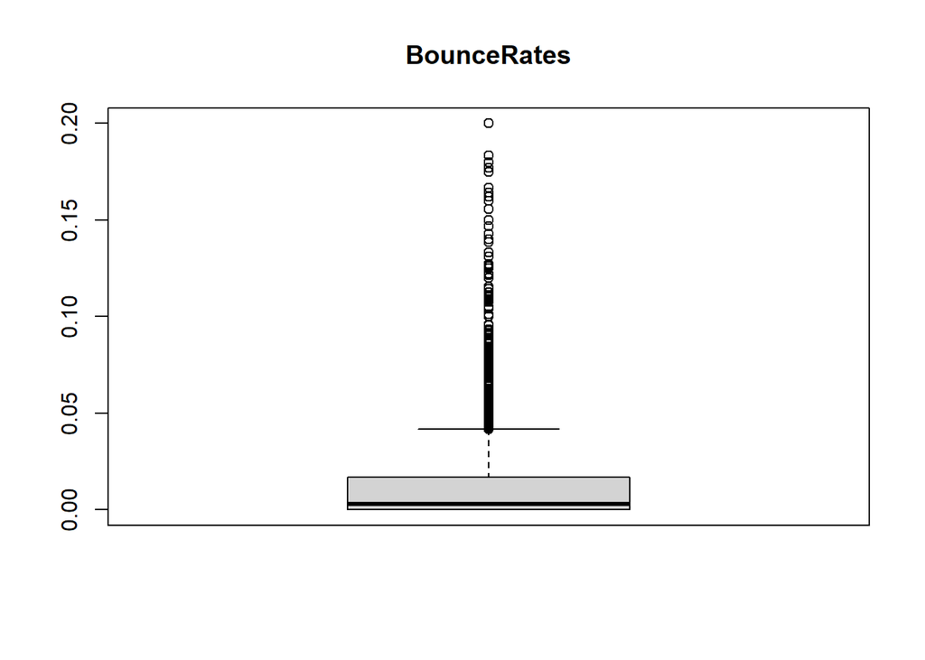

```
## [1] 7
```

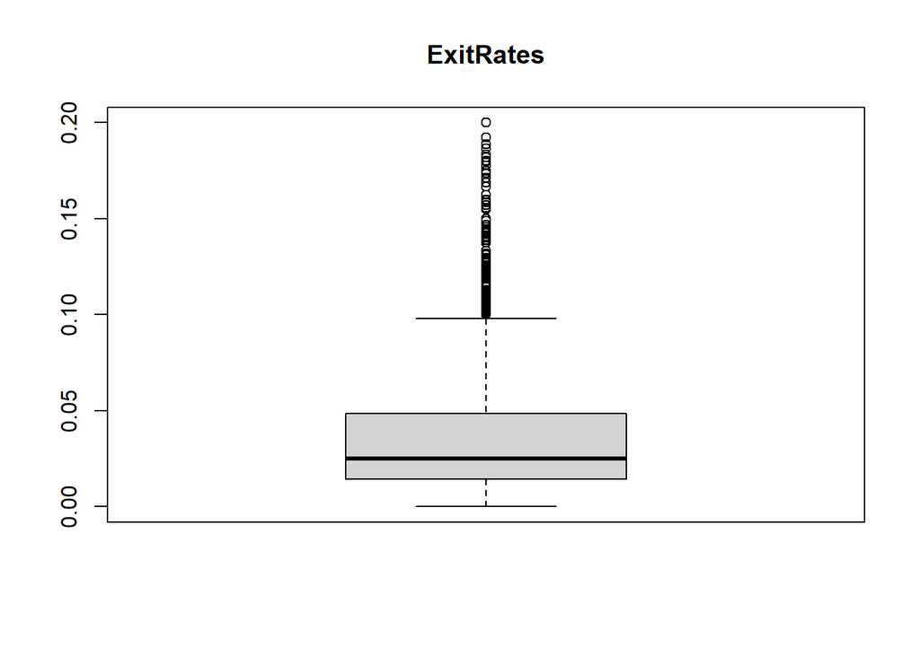

```
## [1] 8
```

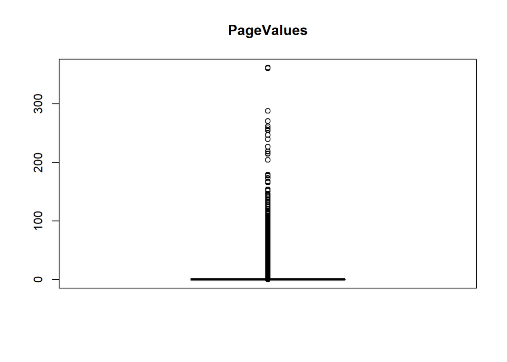

```
## [1] 9
```

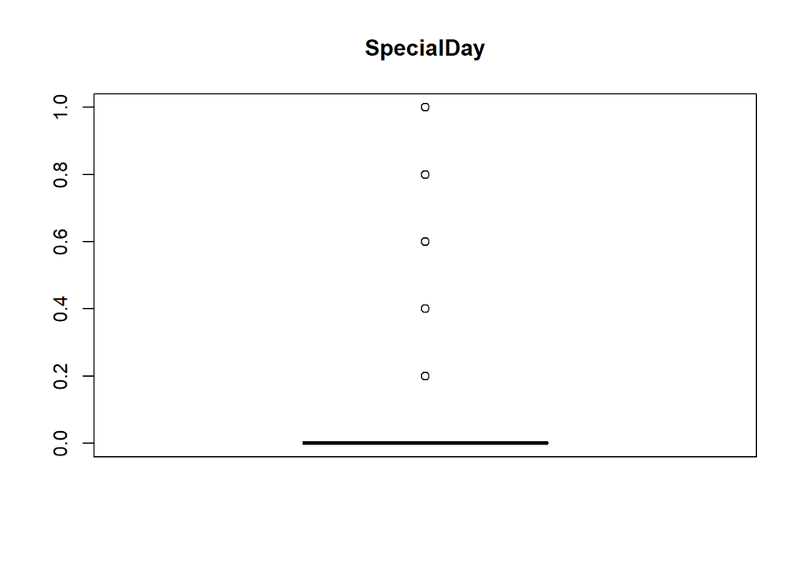

```
## [1] 10
```

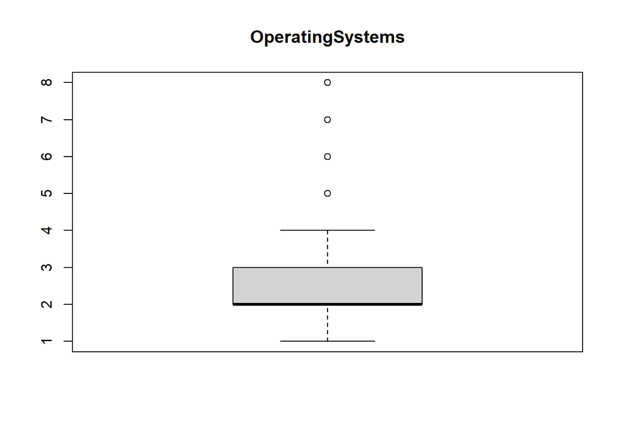

```
## [1] 11
```

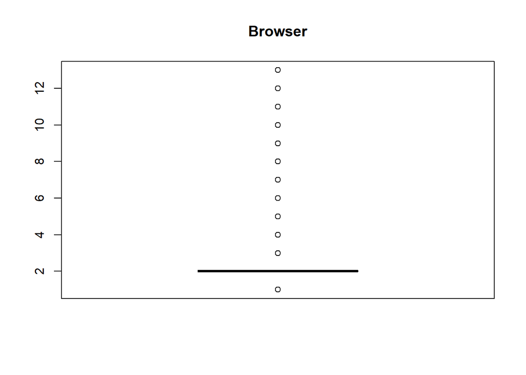

```
## [1] 12
```

[2 more figures not shown]

```
## [1] 14
```

```r
#get the numeric columns
num.col <- Filter(is.numeric, clean.data)
for (i in 1:length(num.col)) {
  boxplot(num.col[,i], main=names(num.col[i]), type="1")
  print(i)
}
```

#Perform Exploratory Data Analysis (Univariate, Bivariate & Multivariate)

```r
desc_stats <- data.frame(
  min = apply(num.col, 2, min),
  median = apply(num.col, 2, median),
  mean_df = apply(num.col, 2, mean),
  SD = apply(num.col, 2, sd),
  max = apply(num.col, 2, max)
)
desc_stats <- round(desc_stats,1)
head(desc_stats)
```

```
##                         min median mean_df     SD     max
## Administrative            0    1.0     2.3    3.3    27.0
## Administrative_Duration  -1    9.0    81.6  177.5  3398.8
## Informational             0    0.0     0.5    1.3    24.0
## Informational_Duration   -1    0.0    34.8  141.4  2549.4
## ProductRelated            0   18.0    32.1   44.6   705.0
## ProductRelated_Duration  -1  610.2  1207.5 1919.3 63973.5
```

Seeing how the different columns are on different scales we need to normalize the data

```r
num.col <- scale(num.col)
head(desc_stats)
```

```
##                         min median mean_df     SD     max
## Administrative            0    1.0     2.3    3.3    27.0
## Administrative_Duration  -1    9.0    81.6  177.5  3398.8
## Informational             0    0.0     0.5    1.3    24.0
## Informational_Duration   -1    0.0    34.8  141.4  2549.4
## ProductRelated            0   18.0    32.1   44.6   705.0
## ProductRelated_Duration  -1  610.2  1207.5 1919.3 63973.5
```

```r
library(tidyverse)
```

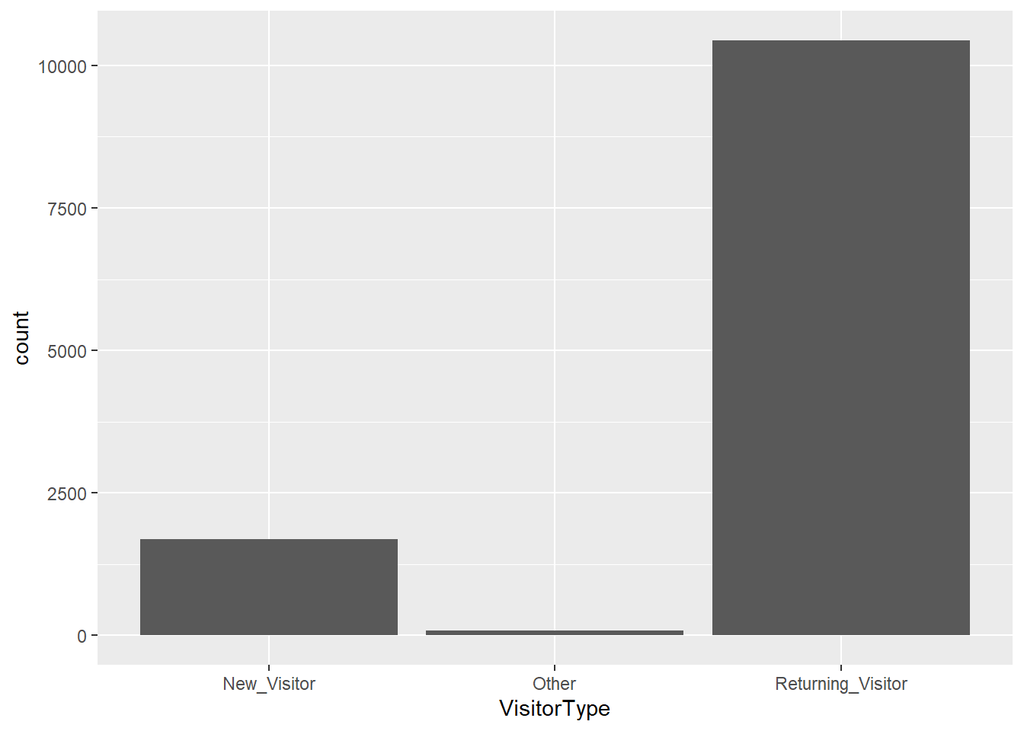

```r
ggplot(clean.data) +
  geom_bar(mapping = aes(x = VisitorType))
```

Returning visitors are the most frequent customers to the site.

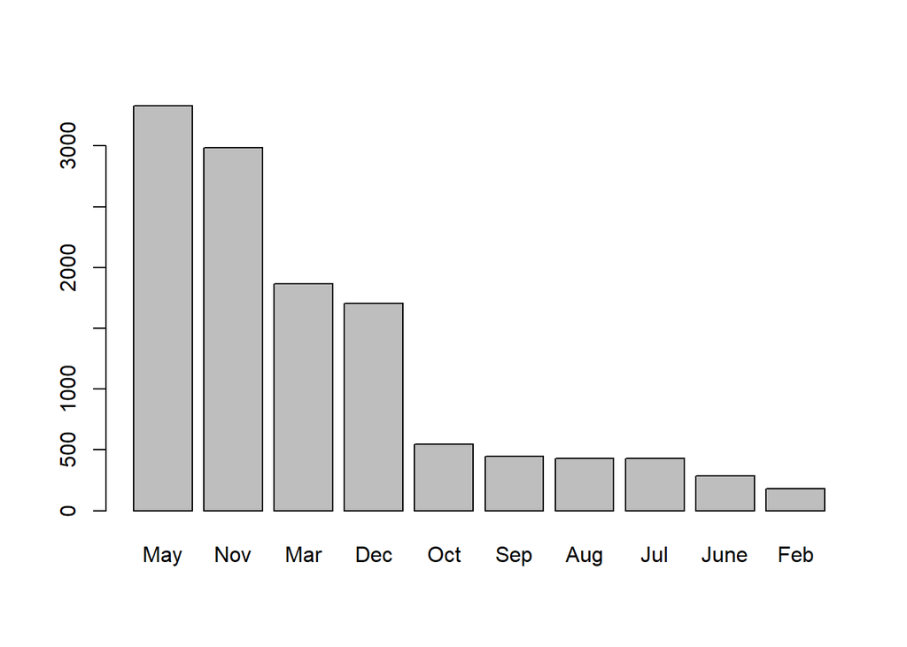

```r
month_frq <- table(clean.data$Month)
barplot(sort(month_frq, decreasing = TRUE))
```

May and November registered the highest traffic to the site.

*Bivariate analysis*

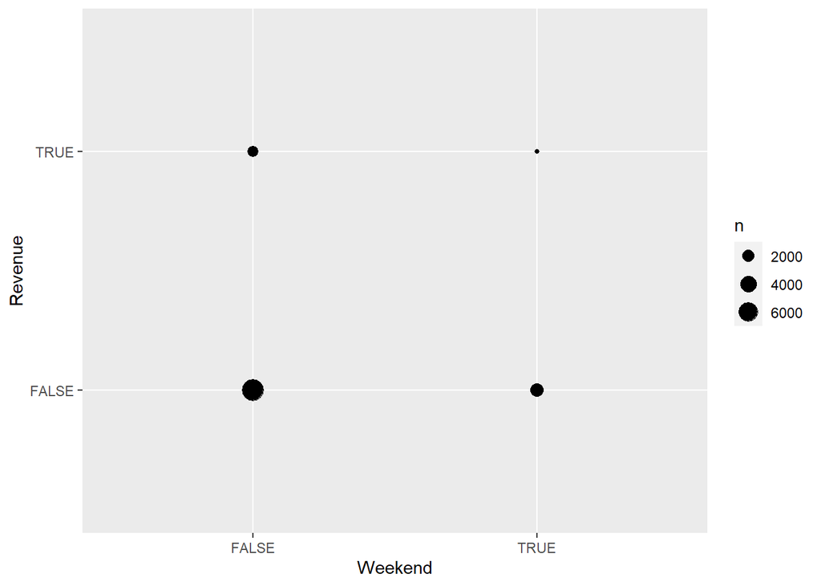

```r
ggplot(data = clean.data) +
  geom_count(mapping = aes(x = Weekend, y = Revenue))
```

Most revenues are not generated during the weekend.

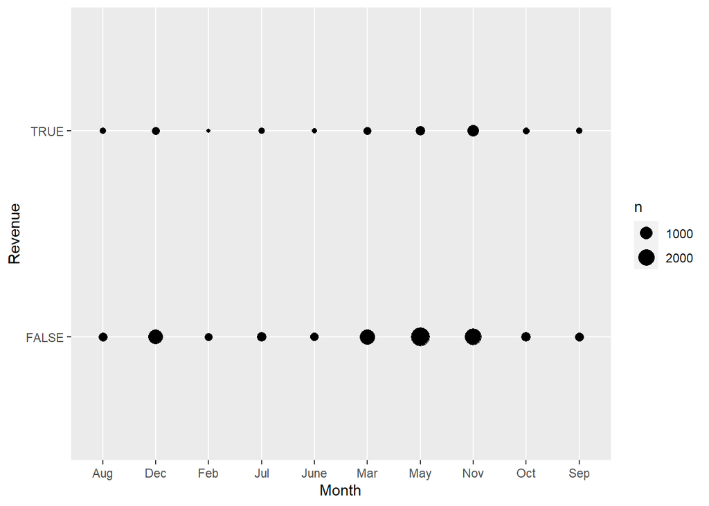

```r
ggplot(data = clean.data) +
  geom_count(mapping = aes(x = Month, y = Revenue))
```

May, November, March, December registered the highest amount of revenue corresponding to the large traffic experienced in these months.

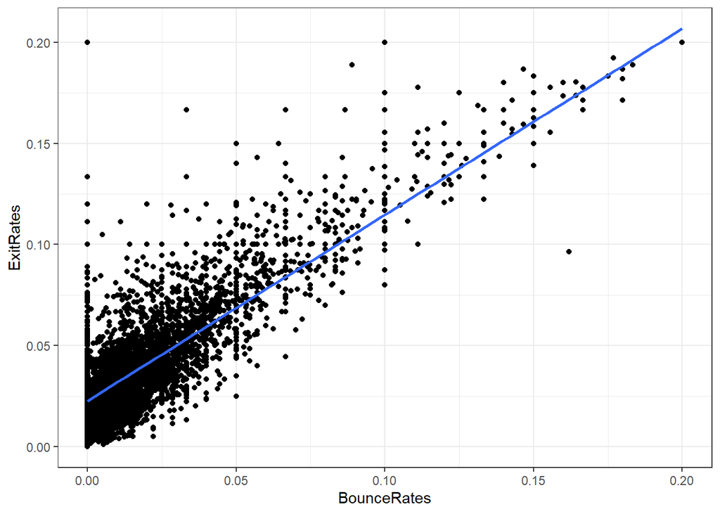

```r
ggplot(clean.data, aes(x = BounceRates, y = ExitRates)) +
  geom_point() +
  geom_smooth(method = 'lm', se = FALSE) +
  theme_bw()
```

The exit and bounce rates show a positive correlation.

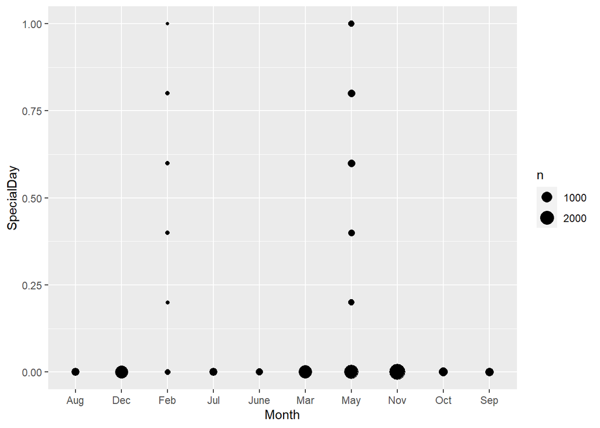

```r
ggplot(data = clean.data) +
 geom_count(mapping = aes(y = SpecialDay, x = Month))
```

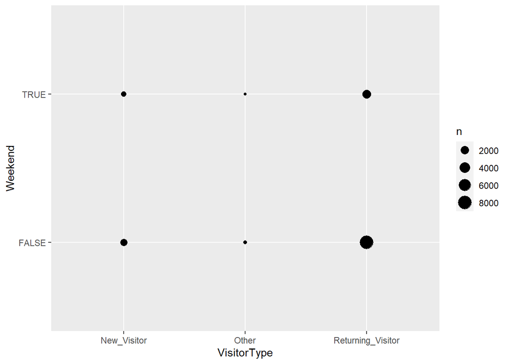

```r
ggplot(data = clean.data) +
  geom_count(mapping = aes(x = VisitorType, y = Weekend))
```

During the weekends, there are no many returning visitors. but their number is higher than that of new visitors.

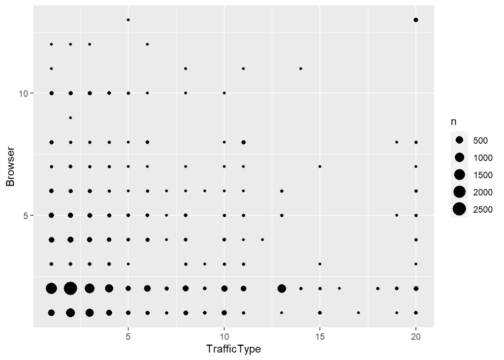

```r
ggplot(data = clean.data) +
  geom_count(mapping = aes(x = TrafficType, y = Browser))
```

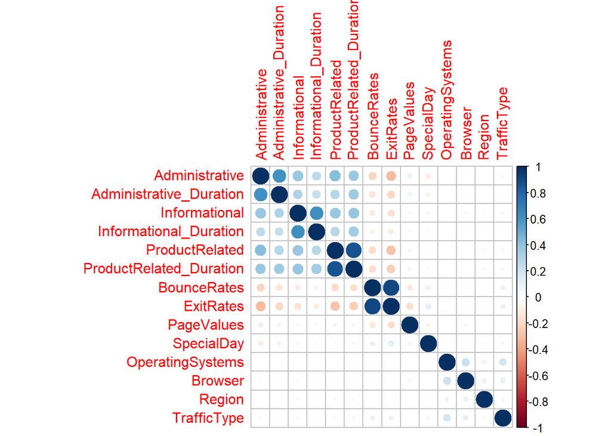

```r
library(corrplot)
corrplot(cor(num.col))
```

*Feature Selection*

Some of the columns are ambiguous and hence difficult to understand. We can’t really tell what the values represent. We’ll drop them. like the browser, traffic type, administrative, informational etc. I know what the labels mean but not what the values represent.

These variables show high correlation so does the exit and bounce rates so I’ll pick one.

```r
clean.data2 <- clean.data[c(2,4,6,8,9,11,16)]
head(clean.data2)
```

```
##   Administrative_Duration Informational_Duration ProductRelated_Duration
## 1                       0                      0                0.000000
## 2                       0                      0               64.000000
## 3                      -1                     -1               -1.000000
## 4                       0                      0                2.666667
## 5                       0                      0              627.500000
## 6                       0                      0              154.216667
##   ExitRates PageValues Month       VisitorType
## 1 0.2000000          0   Feb Returning_Visitor
## 2 0.1000000          0   Feb Returning_Visitor
## 3 0.2000000          0   Feb Returning_Visitor
## 4 0.1400000          0   Feb Returning_Visitor
## 5 0.0500000          0   Feb Returning_Visitor
## 6 0.0245614          0   Feb Returning_Visitor
```

#Implement the Solution

##Hierarchical clustering

Remember that revenue is our label and it has 2 options True or False so our clusters need to show us the same.

```r
# First we use the dist() function to compute the Euclidean distance between observations,
d <- dist(clean.data2, method = "euclidean")
```

*Average method*

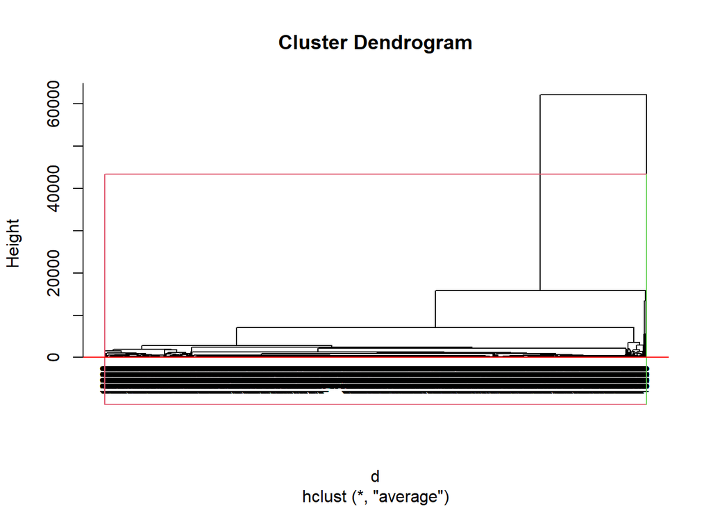

```r
hc.av <- hclust(d, method = "average")

# plot the obtained dendrogram
plot(hc.av, cex = 0.6, hang = -1)
rect.hclust(hc.av , k = 2, border = 2:6)
abline(h = 2, col = 'red')
```

```r
coph.av <- cor(d, cophenetic(hc.av))
coph.av
```

```
## [1] 0.9249951
```

*Wards Method*

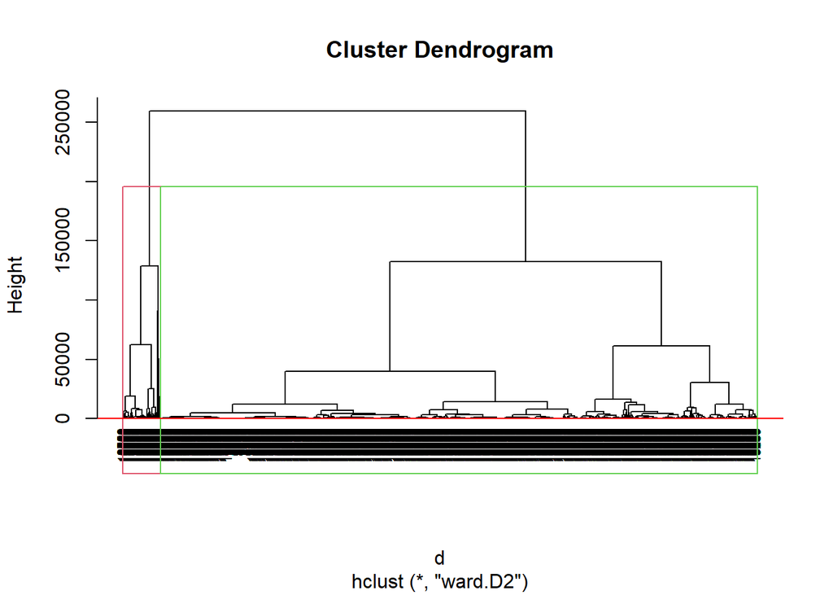

```r
hc.wd2 <- hclust(d, method = "ward.D2" )

# Lastly, we plot the obtained dendrogram
plot(hc.wd2, cex = 0.6, hang = -1)
rect.hclust(hc.wd2 , k = 2, border = 2:6)
abline(h = 2, col = 'red')
```

```r
coph.wd2 <- cor(d, cophenetic(hc.wd2))
coph.wd2
```

```
## [1] 0.693406
```

*Complete method*

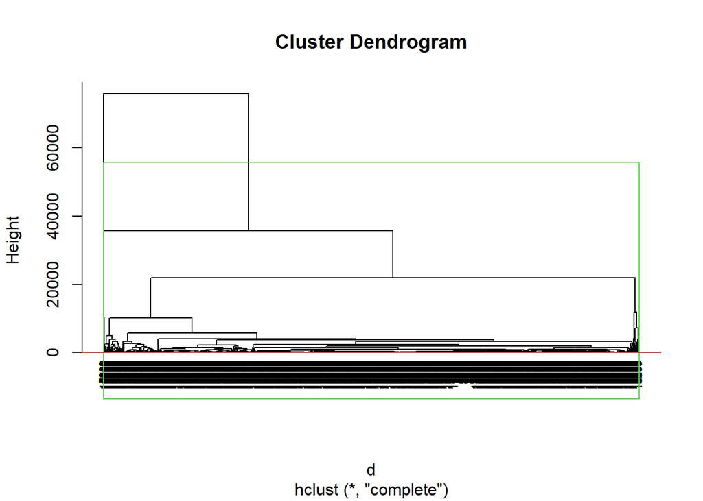

```r
hc.comp <- hclust(d, method = "complete" )

# Lastly, we plot the obtained dendrogram
plot(hc.comp, cex = 0.6, hang = -1)
rect.hclust(hc.comp , k = 2, border = 2:6)
abline(h = 2, col = 'red')
```

```r
coph.comp <- cor(d, cophenetic(hc.comp))
coph.comp
```

```
## [1] 0.9346368
```

Using Agnes function**

```r
library("cluster")
res.agnes <- agnes(x = clean.data2, # data matrix
                   stand = TRUE, # Standardize the data
                   metric = "euclidean", # metric for distance matrix
                   method = "average" # Linkage method
                   )
coph.res.agnes <- cophenetic(res.agnes)
coph.agnes <- cor(d, coph.res.agnes)
```

#Challenge the Solution

*Using K-Means*

```r
suppressPackageStartupMessages(library("factoextra"))
library(cluster)
library(dplyr)

num.col2 <- Filter(is.numeric, clean.data2)
data.k <- kmeans(na.omit(num.col2), 2, 10)
print(data.k)
```

```
## K-means clustering with 2 clusters of sizes 933, 11278
##
## Cluster means:
##   Administrative_Duration Informational_Duration ProductRelated_Duration
## 1               207.80700              146.35696               6094.0746
## 2                71.19753               25.57844                803.2623
##    ExitRates PageValues
## 1 0.02076263   7.345740
## 2 0.04321922   5.830907
##
## Clustering vector:
##     1     2     3     4     5     6     7     8     9    10    11    12    13
##     2     2     2     2     2     2     2     2     2     2     2     2     2
##    14    15    16    17    18    19    20    21    22    23    24    25    26
##     2     2     2     2     2     2     2     2     2     2     2     2     2
```

[output cut: 1885 more lines]

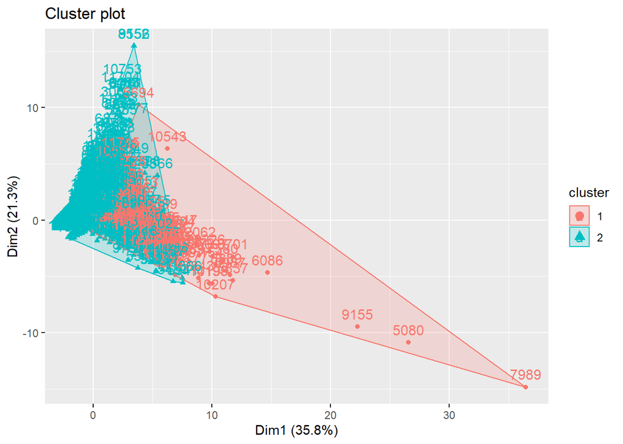

```r
fviz_cluster(data.k, data = num.col2)
```

*Determining Optimal clusters (k) Using Elbow method*

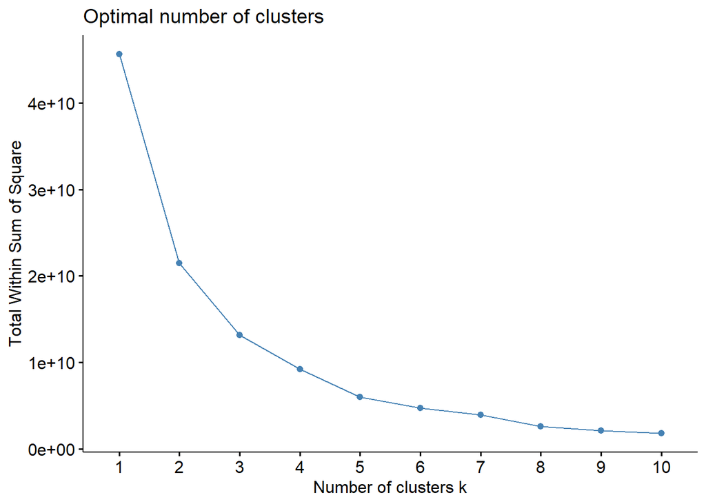

```r
fviz_nbclust(x = num.col2,FUNcluster = kmeans, method = 'wss' )
```

*Determining Optimal clusters (k) Using Average Silhouette Method*

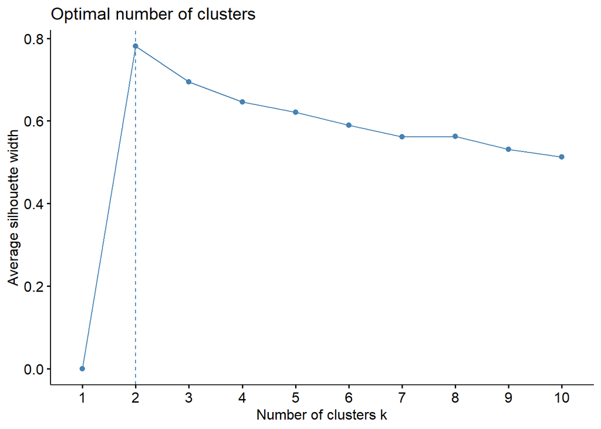

```r
fviz_nbclust(x = num.col2,FUNcluster = kmeans, method = 'silhouette' )
```

#Conclusion Using the 2 clustering methods we found that implementing kmeans gives us a better visualization of the clusters compared to the hierarchical clustering method.

#Follow up Questions

We need more information about what the values in lthe respective columns represent. Due to low computational power we could not dig further inside the clusters to get bet insights of our analysis.